# Estatística Espacial

Shirlei

6 de outubro de 2018

- Abaixo está sendo exibido o mapa do Estado do Rio de Janeiro

```r
#-------------------------------------------------------------------------------------#
# ------------------------------- Script: Dados de Area ------------------------------#
#-------------------------------------------------------------------------------------#

#Nao esqueca de iniciar sua pasta de trabalho!!! Faca o R "enxergar" o diretorio
#no qual voce ira trabalhar.

#setwd("/Users/jony/Documents/FGV/MBA/2 Aplicacoes de Estatistica Espacial/Aula/Codigos em R/2 Revisao")

#Carregando o pacote rgdal
library(rgdal)
## Lendo o shapefile com os bairros da cidade de Recife
RJ = readOGR("municipiosrj.shp")
```

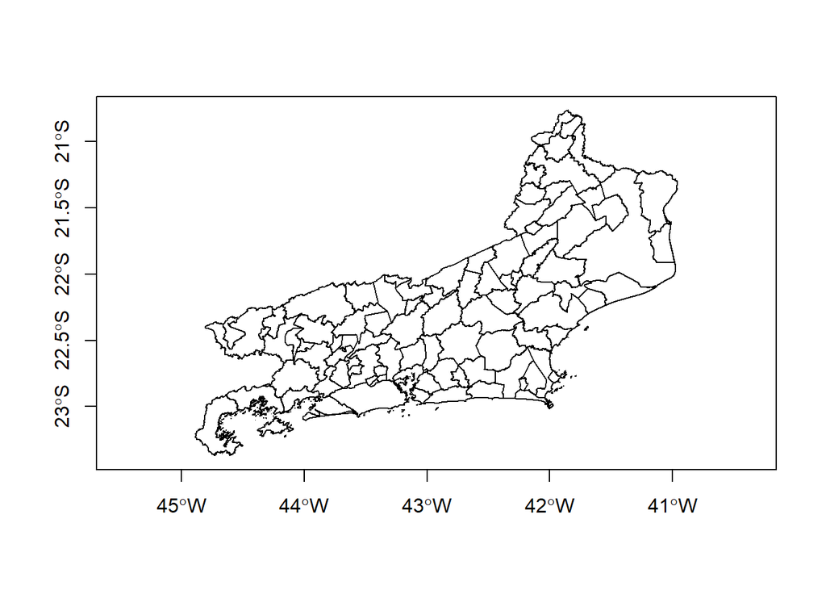

```r
## Plotando o shapefile com todos os bairros da cidade de Recife
plot(RJ, axes = TRUE)
```

- Carregando a base de casos de Hanseniase nos Municípios do Estado do Rio de Janeiro.

```r
#Carregando o pacote tidyverse
library(tidyverse)
#Lendo o arquivo de dados
#Registro das vendas vendas do produto de interesse
base = read_csv("hanseniase.csv")
#Visualinado a base de dados
base
```

```
## # A tibble: 92 x 3
##    Municipio          Casos ID_OBJETO
##    <chr>              <int>     <int>
##  1 Angra dos Reis        81        93
##  2 Aperibe                4        94
##  3 Araruama              65        95
##  4 Areal                  2        96
##  5 Armacao dos Buzios    14        97
##  6 Arraial do Cabo        8        98
##  7 Barra do Pirai        14        99
##  8 Barra Mansa           14       100
##  9 Belford Roxo         105       101
## 10 Bom Jardim             4       102
## # ... with 82 more rows
```

```r
#Fazendo a relacao dos dois data frames
RJ@data = left_join(RJ@data, base, by = "ID_OBJETO")

#Visualizando o data frame existente em recife acrescido da variavel
head(RJ@data)
```

```
##   ID_OBJETO                  NOME NOMEABREV GEOMETRIAA GEOCODIGO
## 1        93        Angra dos Reis      <NA>        Sim   3300100
## 2        94              AperibÃ©      <NA>        Sim   3300159
## 3        95              Araruama      <NA>        Sim   3300209
## 4        96                 Areal      <NA>        Sim   3300225
## 5        97 ArmaÃ§Ã£o dos BÃºzios      <NA>        Sim   3300233
## 6        98       Arraial do Cabo      <NA>        Sim   3300258
##   ANODEREFER          Municipio Casos
## 1       2016     Angra dos Reis    81
## 2       2016            Aperibe     4
## 3       2016           Araruama    65
## 4       2016              Areal     2
## 5       2016 Armacao dos Buzios    14
## 6       2016    Arraial do Cabo     8
```

## Nesta etapa estamos exibindo as ocorrencias de hanseniase por área (Município).

- Ao analisar o cartograma, observamos que as áreas com maior incidencia, onde as cidades vizinhas acompanham o mesmo comportamento o mapa se deformou em relação a geografia original, exibindo um efeito lupa.

```r
#Carregando o pacote sp e RColorBrewer
library(sp)
library(RColorBrewer)
library(cartography)
library(tmap)

library(cartogram)

#-------------------------------------------------------------------------------------#
# ----------------- Mapa Cartograma: Numero de casos de hanseniase -------------------#
#-------------------------------------------------------------------------------------#

dados_cartograma = cartogram(RJ,  weight = "Casos", itermax = 5)
```

```
##
## Please use cartogram_cont() instead of cartogram().
```

```
## Mean size error for iteration 1: 8.81824344979315
```

```
## Mean size error for iteration 2: 7.65331942993453
```

```
## Mean size error for iteration 3: 6.72720661347884
```

```
## Mean size error for iteration 4: 5.89676029387822
```

```
## Mean size error for iteration 5: 5.14051377527433
```

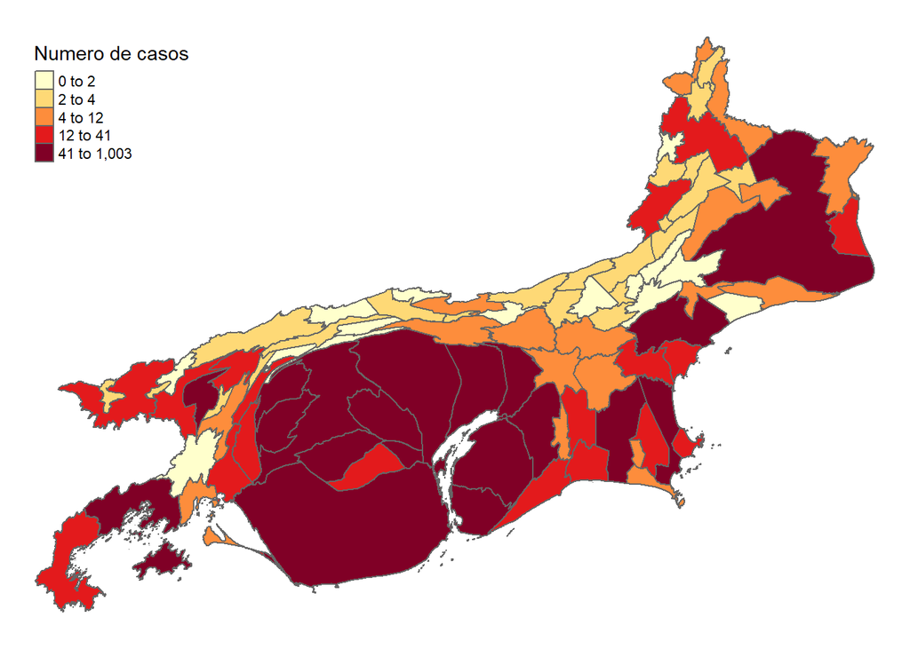

```r
## cartogram - constroi cartogramas com base no algoritmo de rubber sheet distortion
#Argumentos:
#shp - um objeto da classe SpatialPolygonsDataFrameclass
#weight - o nome da variavel contida em shp que sera utilizada para o peso
#itermax - numero maximo de interacoes para a transformacao do cartograma

tm_shape(shp = dados_cartograma) +
  tm_polygons(col = "Casos",
              style="quantile", # "cat", "fixed", "sd", "equal", "pretty", "quantile", "kmeans", "hclust", "bclust", "fisher", and "jenks"
              palette = brewer.pal(9, "YlOrRd"), title=c("Numero de casos")) +
  tm_layout(frame=FALSE)
```

```r
#Argumentos:
#shp - um objeto da classe SpatialPolygonsDataFrameclass
#col - a variavel que deseja plotar
#style - tipo de divisao para criar os intervalos
#palette - paleta de cores
#title - Titulo da legenda
#frame - FALSE faz com que um quadro ao redor da figura nao seja plotado
```

- Ao analisar o mapa coroplético, observamos que as áreas com maior incidencia, foram bem representadas pela escala de cor, porém a dimensão do problema ficou camuflada pela área que não ficou em destaque.

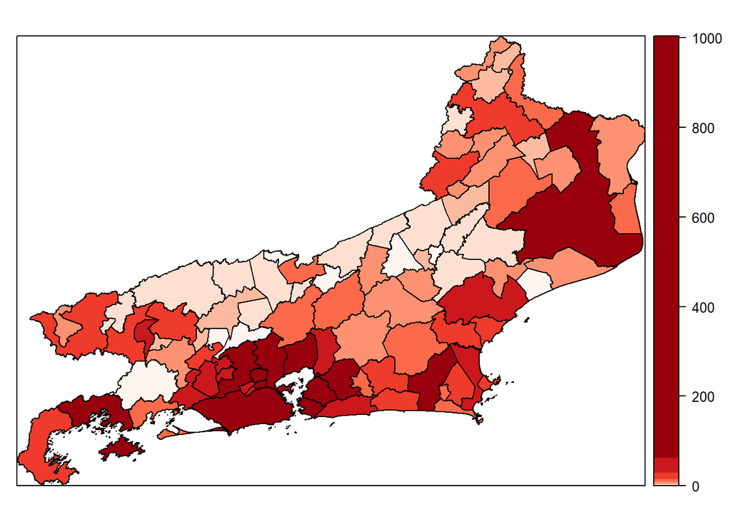

```r
#-------------------------------------------------------------------------------------#
# ------------------ Mapas coropleticos: Numero de casos de hanseniase  -----------------#
#-------------------------------------------------------------------------------------#


#Plotando o mesmo mapa coropletico, usando funcoes diferentes

#Usando a funcao spplot

#Criando os intervalos com base em quantis
intervalos1=quantile(RJ$Casos, probs = seq(0,1,0.125))
intervalos1[9] = intervalos1[9] + 1

#Plotando o mapa com tons avermelhados
spplot(obj = RJ, zcol = c("Casos"), at = intervalos1, col.regions =brewer.pal(8, "Reds")) #Outras opções de cores: Greens, BrBG, Accent
```

- Ao analisar o mapa coroplético com função ChoroLayer, observamos que as áreas não estão sendo bem representadas pela variação da escala.

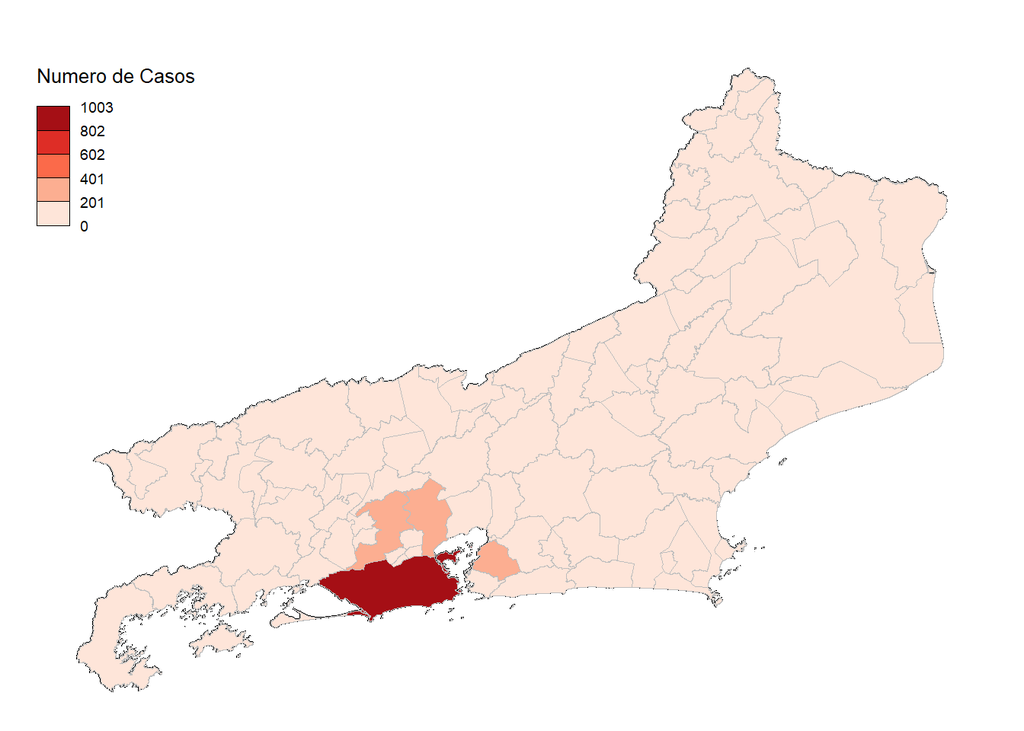

```r
#Usando a funcao choroLayer
par(mar = c(0.5,0.5,1.5,0.5))
plot(RJ)
choroLayer(spdf = RJ, var = "Casos", border = "gray",
           method = "equal", # "sd", "equal", "quantile", "fisher-jenks","q6" or "geom"
           nclass = 5, lwd = 0.4, col = brewer.pal(5, "Reds"),
           legend.pos = "topleft", legend.title.txt = "Numero de Casos", add= TRUE)
```

```r
## choroLayer - funcao para plotar dados espaciais com atributos
#Argumentos:
#spdf - um objeto da classe sf
#var - a variavel/atributo que deseja plotar
#border - cor das linhas que definem os poligonos
#method - o metodo que vai definir os intervalos de classes
#nclass - o numero de classes
#lwd - a espessura da linha dos poligonos
#col - vetor com as cores
#legend.pos - posicao da legenda
#legend.title.txt - titulo do texto
#add - para adicionar sobre o grafico que esta plotado
```

### Conclusão Parcial (Mapas)

Concluímos analisando os últimos mapas que para termos uma visão que reflita melhor a realidade, precisamos considerar os seguintes itens.

- Dimensionar bem a escala/palheta de cores
- Observar a influência da densidade populacional
- Observar referencias externas que expliquem melhor o fenomeno ex: Indicadores da ONU, IDH
- Pode ser interessante refazer os novos mapas com a taxa percapta no lugar da taxa de ocorrências.

## Definindo vizinhanças

```r
#-------------------------------------------------------------------------------------#
# -------------------- Criando a matriz W baseado em contiguidade  -------------------#
#-------------------------------------------------------------------------------------#

#Carregando o pacote stringr
library(spdep)
#W com o criterio queen
W.queen = poly2nb(pl = RJ, row.names = RJ$NOME, queen = TRUE)

## poly2nb - uma das funcoes para criar a matriz W
#Argumentos:
#pl - um objeto da classe SpatialPolygons
#row.names - um vetor indicando os rotulos das sub-regioes
#queen - se TRUE, cria o criterio queen

#Visualizando a quantidade de links criados
summary(W.queen)
```

```
## Neighbour list object:
## Number of regions: 92
## Number of nonzero links: 456
## Percentage nonzero weights: 5.387524
## Average number of links: 4.956522
## Link number distribution:
##
##  1  2  3  4  5  6  7  8  9 10
##  3  7 15 16 14 16 10  7  2  2
## 3 least connected regions:
## ArmaÃ§Ã£o dos BÃºzios Itatiaia Parati with 1 link
## 2 most connected regions:
## Campos dos Goytacazes PetrÃ³polis with 10 links
```

```r
#Extraindo as coordenadas
coordenadas = coordinates(obj = RJ)
head(coordenadas)
```

```
##        [,1]      [,2]
## 0 -44.38540 -22.93622
## 1 -42.13467 -21.65229
## 2 -42.29291 -22.75526
## 3 -43.12152 -22.23538
## 4 -41.95137 -22.77598
## 5 -42.16850 -22.92151
```

Mapa dos vizinhos definido pelo critério Queen

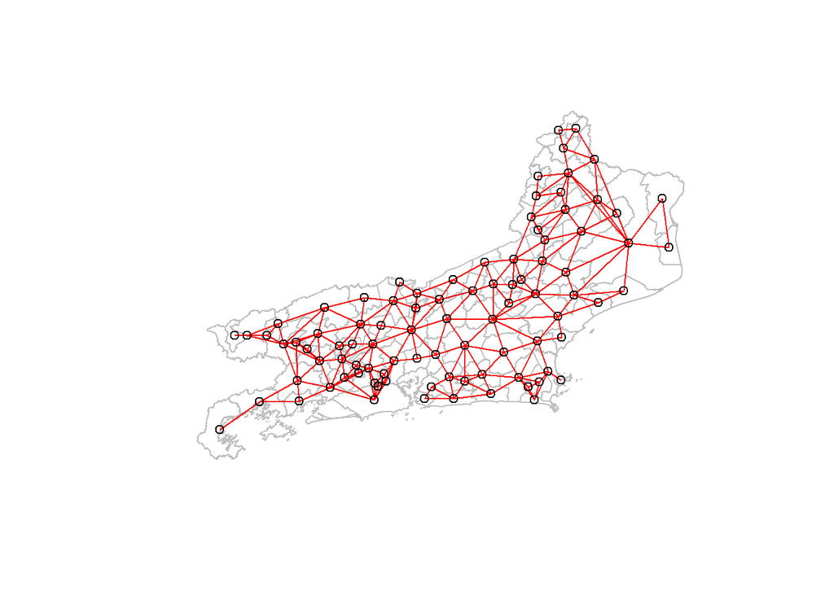

```r
## coordinates - define coordenadas espaciais para criar um objeto espacial
#Argumentos:
#obj - um objeto da classe SpatialPolygons


#Plotando a estrutura de vizinhanca criada
plot(RJ, border = "grey")
plot(W.queen, coordenadas, add = TRUE, col = "red")
```

```r
#Visualizando a matriz W com o criterio queen
mat.W.queen <- nb2mat(W.queen, style = "B")
colnames(mat.W.queen) <- rownames(mat.W.queen)
mat.W.queen[1:5,1:5]
```

```
##                       Angra dos Reis AperibÃ© Araruama Areal
## Angra dos Reis                     0        0        0     0
## AperibÃ©                           0        0        0     0
## Araruama                           0        0        0     0
## Areal                              0        0        0     0
## ArmaÃ§Ã£o dos BÃºzios              0        0        0     0
##                       ArmaÃ§Ã£o dos BÃºzios
## Angra dos Reis                            0
## AperibÃ©                                  0
## Araruama                                  0
## Areal                                     0
## ArmaÃ§Ã£o dos BÃºzios                     0
```

```r
#W com o criterio rook
W.rook = poly2nb(pl = RJ, row.names = RJ$NOME, queen = FALSE)

#Visualizando a quantidade de links criados
summary(W.rook)
```

```
## Neighbour list object:
## Number of regions: 92
## Number of nonzero links: 436
## Percentage nonzero weights: 5.151229
## Average number of links: 4.73913
## Link number distribution:
##
##  1  2  3  4  5  6  7  8  9
##  3  7 16 18 18 12 10  5  3
## 3 least connected regions:
## ArmaÃ§Ã£o dos BÃºzios Itatiaia Parati with 1 link
## 3 most connected regions:
## Campos dos Goytacazes Nova Friburgo PetrÃ³polis with 9 links
```

Mapa dos vizinhos definido pelo critério Rook

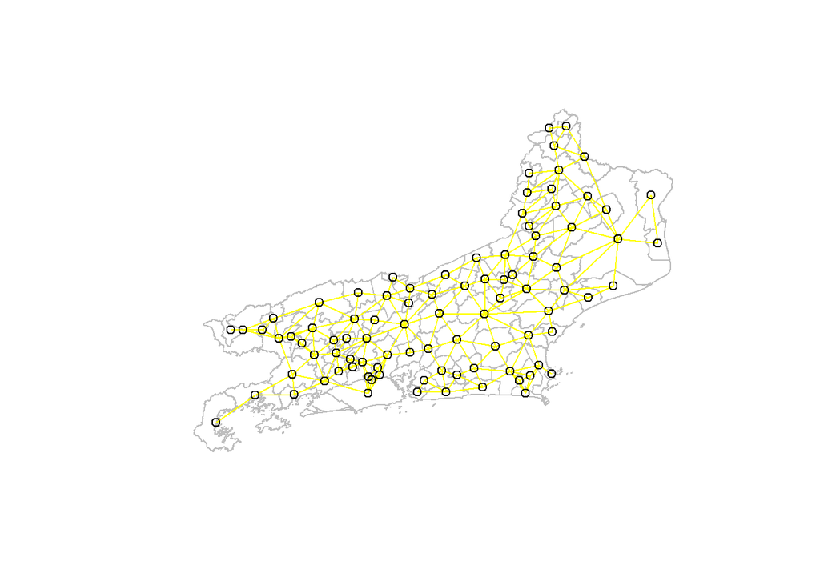

```r
#Plotando a estrutura de vizinhanca criada
plot(RJ, border = "grey")
plot(W.rook, coordenadas, add = TRUE, col = "yellow")
```

Plotando o mapa dos vizinhos com os critérios Queen e Rook juntos, vemos que há poucas diferenças na definição de vizinhos entre os dois critérios.

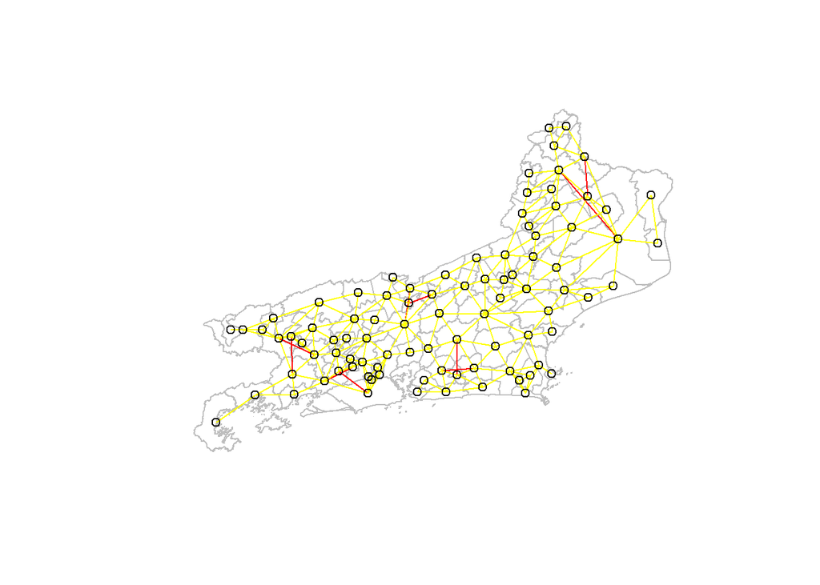

```r
#Sobrepondo as duas estruturas de vizinhanca
plot(RJ, border = "grey")
plot(W.queen, coordenadas, add = TRUE, col = "red")
plot(W.rook, coordenadas, add = TRUE, col = "yellow")
```

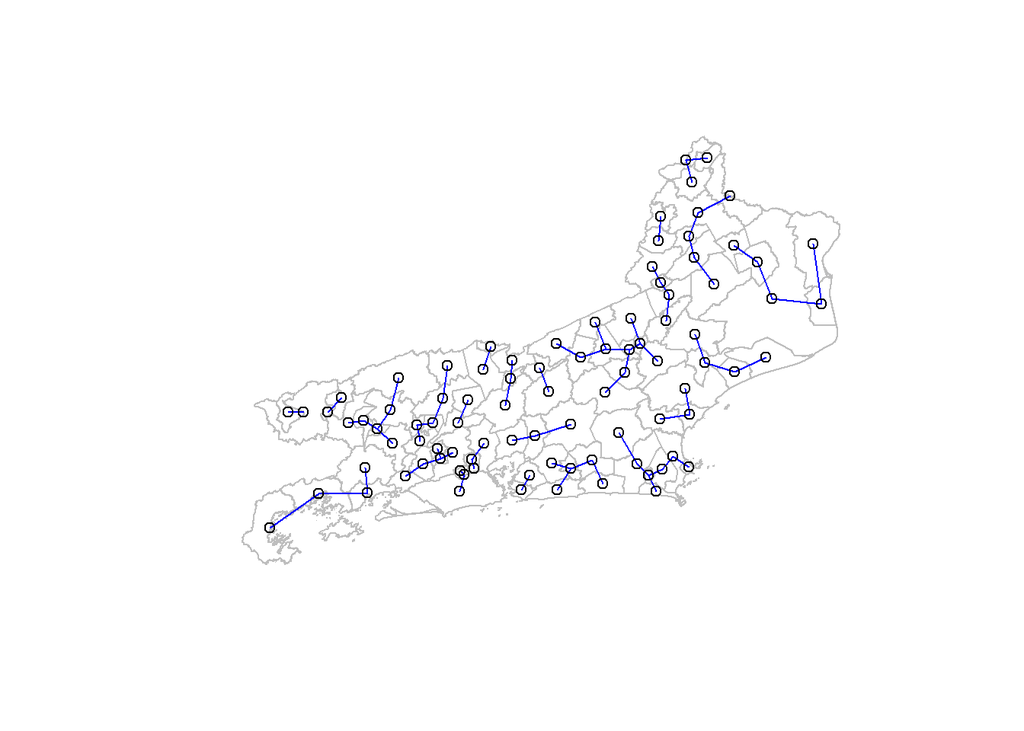

```r
#-------------------------------------------------------------------------------------#
# --------------------- Criando a matriz W baseado em distancia  ---------------------#
#-------------------------------------------------------------------------------------#

#Extraindo os k vizinhos mais proximos
k1viz = knearneigh(x = coordenadas, k = 1)
k3viz = knearneigh(x = coordenadas, k = 3)

## knearneigh - define os k vizinhos mais proximos
#Argumentos:
#x - objeto do tipo SpatialPoints
#k - numero de vizinhos

#Plotando a estrutura de vizinhanca criada
par(mfrow = c(1,1))
#Vizinhanca considerando o vizinho mais proximo
plot(RJ, border = "grey")
plot(knn2nb(knn = k1viz), coordenadas, add = TRUE, col = "blue")
```

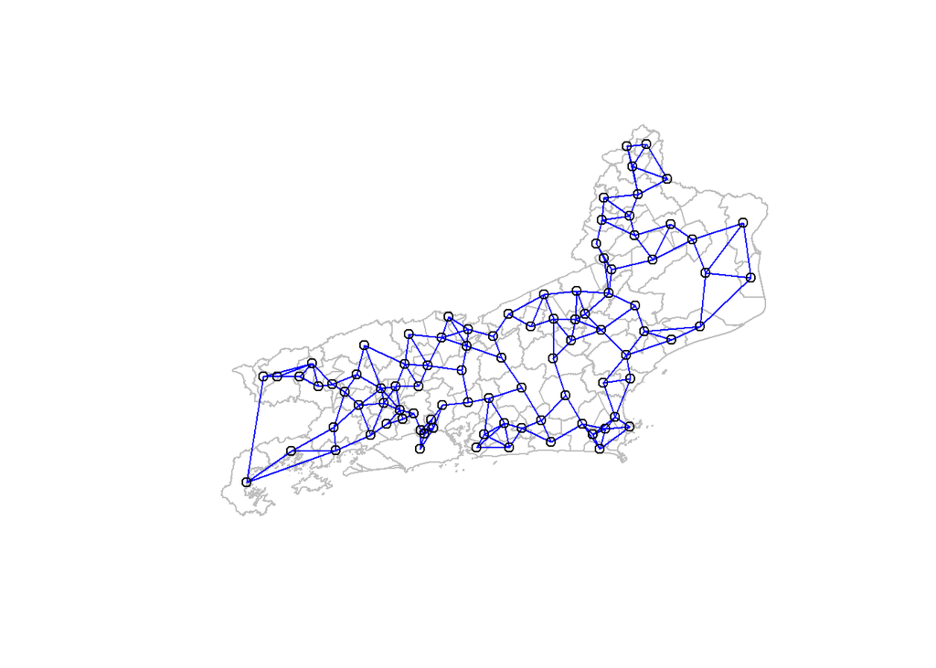

```r
#Vizinhanca considerando os 3 vizinhos mais proximos
plot(RJ, border = "grey")
plot(knn2nb(knn = k3viz), coordenadas, add = TRUE, col = "blue")
```

```r
par(mfrow = c(1,1))

## knn2nb - define uma lista de vizinhanca de um objeto knn
#Argumentos:
#knn - um objeto retornado por knearneigh
```

Considerando como vizinhos apenas os K vizinhos mais próximos, algumas cidades deixam de ser consideradas viznhas mesmo tendo fronteira. No como essa doença se propaga pelo ar, entendemos que faz mais sentido considerar como vizinho todas as cidades que fazem fronteira.

```r
#-------------------------------------------------------------------------------------#
# ---------------- Definindo os pesos associados aos elementos de W  -----------------#
#-------------------------------------------------------------------------------------#


## Lista de vizinhanca espacial com pesos
recWQW <- nb2listw(neighbours = W.queen, style="W") #outras opcoes: B, C, S e U
recWQW$weights
```

[output not shown]

[output cut: 233 more lines]

```
## [1] 0.125 0.125 0.125 0.125 0.125 0.125 0.125 0.125
##
## [[92]]
## [1] 0.2 0.2 0.2 0.2 0.2
##
## attr(,"mode")
## [1] "binary"
## attr(,"W")
## [1] TRUE
## attr(,"comp")
## attr(,"comp")$d
##  [1]  3  3  8  4  1  4  7  8  4  4  5  5  7  7  3  2 10  7  3  4  6  6  5
## [24]  6  7  4  5  3  6  7  6  6  8  1  5  2  6  4  3  3  5  5  5  8  4  4
## [47]  3  2  9  9  7  7  1  4 10  3  8  2  3  4  3  3  4  6  6  3  2  7  5
## [70]  6  2  7  3  2  5  4  6  4  6  4  4  6  5  6  5  6  8  6  5  3  8  5
```

```r
recWQB <- nb2listw(neighbours = W.queen, style="B") #outras opcoes: B, C, S e U
recWQB$weights
```

[output not shown]

[output cut: 225 more lines]

```
## [1] 1 1 1 1 1
##
## [[90]]
## [1] 1 1 1
##
## [[91]]
## [1] 1 1 1 1 1 1 1 1
##
## [[92]]
## [1] 1 1 1 1 1
##
## attr(,"mode")
## [1] "binary"
## attr(,"B")
## [1] TRUE
```

```r
## nb2listw - define uma lista de vizinhanca com pesos espaciais
#Argumentos:
#neighbours - um objeto da classe nb
#style - tipo de peso
```

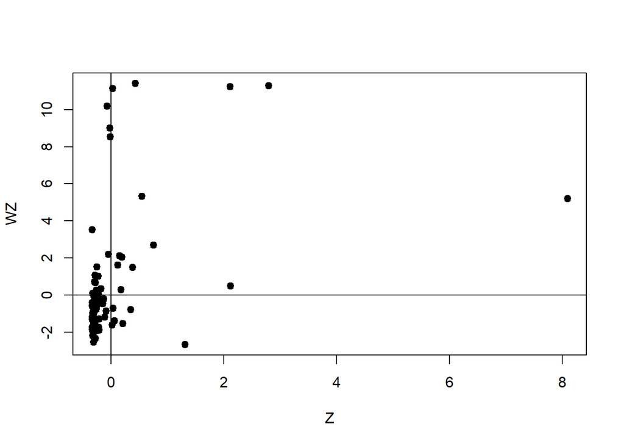

```r
#-------------------------------------------------------------------------------------#
# ------------------------ Avaliando variavel x media movel  -------------------------#
#-------------------------------------------------------------------------------------#

#Padronizando os dados
casos_padronizada <- scale(x = base$Casos)
casos_W <- mat.W.queen %*% casos_padronizada

## scale - padroniza um conjunto de valores
#Argumentos:
#x - conjunto de valores a ser padronizado


#Plotando variavel versus media movel
plot(casos_padronizada, casos_W, pch = 19, lwd = 2, cex = 0.9, xlab = "Z", ylab = "WZ")
abline(v=0, h=0)
```

```r
#-------------------------------------------------------------------------------------#
# ------------------------------ Autocorrelacao global  ------------------------------#
#-------------------------------------------------------------------------------------#

#Calculando o indice de moram considerando uma estrutura de vizinhanca queen com padronizacao pelas linhas
moran.test(x = RJ$Casos,listw = recWQW)
```

```
##
##  Moran I test under randomisation
##
## data:  RJ$Casos
## weights: recWQW
##
## Moran I statistic standard deviate = 4.5273, p-value = 2.987e-06
## alternative hypothesis: greater
## sample estimates:
## Moran I statistic       Expectation          Variance
##       0.205263877      -0.010989011       0.002281604
```

```r
## moran.test - calcula o indice global de moran
#Argumentos:
#x - a variavel de interesse
#listw - um objeto do tipo nb2listw

#Calculando o indice de moram considerando uma estrutura de vizinhanca queen com pesos iguais
moran.test(RJ$Casos,recWQB)
```

```
##
##  Moran I test under randomisation
##
## data:  RJ$Casos
## weights: recWQB
##
## Moran I statistic standard deviate = 6.2473, p-value = 2.089e-10
## alternative hypothesis: greater
## sample estimates:
## Moran I statistic       Expectation          Variance
##       0.266476269      -0.010989011       0.001972594
```

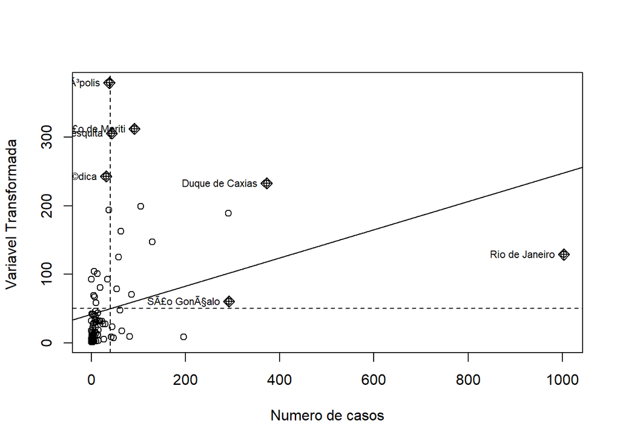

```r
#plotando a variavel com a variavel transformada considerando uma estrutura de vizinhanca queen com padronizacao pelas linhas
moran.plot(x = RJ$Casos,listw = recWQW, pch = 21, xlab = "Numero de casos", ylab = "Variavel Transformada ")
```

```r
## moran.plot - plota a variavel versus os valores transformados em funcao de W
#Argumentos:
#x - a variavel de interesse
#listw - um objeto do tipo nb2listw
```

```r
#-------------------------------------------------------------------------------------#
# ------------------------------ Autocorrelacao local (LISA)  -------------------------------#
#-------------------------------------------------------------------------------------#

#Calculando o Moran Local
moranlocREC = localmoran(x = RJ$Casos,listw = recWQW, na.action=na.exclude,zero.policy=TRUE)

## moranlocREC - calcula o indice local de moran
#Argumentos:
#x - a variavel de interesse
#listw - um objeto do tipo nb2listw

#Visualizando as autocorrelacoes locais
head(moranlocREC)
```

```
##                                 Ii        E.Ii     Var.Ii         Z.Ii
## Angra dos Reis        -0.090194875 -0.01098901 0.15891096 -0.198692011
## AperibÃ©               0.086881075 -0.01098901 0.15891096  0.245512178
## Araruama              -0.039594640 -0.01098901 0.05992892 -0.116851230
## Areal                  0.096682118 -0.01098901 0.11931815  0.311706615
## ArmaÃ§Ã£o dos BÃºzios -0.006479931 -0.01098901 0.47565351  0.006537965
## Arraial do Cabo        0.014746347 -0.01098901 0.11931815  0.074503551
##                       Pr(z > 0)
## Angra dos Reis        0.5787482
## AperibÃ©              0.4030299
## Araruama              0.5465110
## Areal                 0.3776318
## ArmaÃ§Ã£o dos BÃºzios 0.4973917
## Arraial do Cabo       0.4703049
```